# Distribución del pago de los servicios

#### Tabla de contenidos:

1. Notas Preliminares
2. Gases del Caribe
3. Triple A
   1. Datos de la factura
   2. Total pago por habitación
4. Air-e
   1. Tabla de ponderación del consumo
   2. Datos de la factura
   3. Gráfica de los registros de consumo
   4. Datos para tener en cuenta
      1. Diferencias sobre datos de consumo
      2. Valor de corte
      3. Valor del consumo del aire acondicionado
      4. Lectura de contadores internos
      5. Consumo area común
   5. Total a pagar por habitación
5. Movistar
6. Total servicios

## Notas Preliminares

Energía eléctrica: a partir del 2 de agosto de 2025 entraron en funcionamiento los dos primeros contadores internos en la casa (Hab. 1 y Apt.) y el 8 de agosto los otros 2 (Hab.2 y 3). Lo cual modifica la manera en la que se hace la distribución de la factura.

Valor del arriendo: se les recuerda que a partir del 1 de septiembre de 2025 se hará efectivo el incremento en el valor del arriendo anunciado el 1 de agosto de 2025.

## 1. Gases del Caribe

Datos de la factura del gas:

La factura de la casa grande (contrato No.1020307), por un valor total de $78.245 correspondiente al período 07/2025, está para pagar antes del 20 de agosto de 2025. NOTA: Del valor total me corresponde pagar: $31.200.

###### Tabla de contenidos

## 2. Triple A

### 2.1. Datos de la factura

Los siguientes son los datos tomados de la factura de este mes:

La factura del agua (póliza No.121497), por un valor total de $286.934, correspondiente al período: Agosto-2025, está para pagar antes del 16 de agosto de 2025.

### 2.2. Total pago por habitación

| Habitación | Integrante(s) | Ocupación | Total AAA |
| --- | --- | --- | --- |
| Hab. 1 | Andresito y Kevin | 100.00% | $107.600 |
| Hab. 2 | Jorge | 100.00% | $53.800 |
| Hab. 3 | Gary | 33.33% | $17.900 |
| Apt. | Luis y Andrés | 100.00% | $107.600 |

###### Tabla de contenidos

## 3. Air-e

### 3.1. Tabla de ponderación del consumo:

Debido a la instalación de los contadores internos esta sección desaparecerá a partir del siguiente documento. La distribución del consumo no cobijado por los contadores internos (área común) se hará de manera proporcional al consumo reportado por estos contadores.

| Habitación | Integrante(s) | Personas | En_casa | Aparatos | Subtotal | Ocupación | Coeficiente |
| --- | --- | --- | --- | --- | --- | --- | --- |
| Hab. 1 | Andresito y Kevin | 2 | 1 | 5.0 | 8.0 | 100.00% | 8.0 |
| Hab. 2 | Jorge | 1 | 1 | 1.5 | 3.5 | 100.00% | 3.5 |
| Hab. 3 | Gary | 1 | 0 | 0.5 | 1.5 | 33.33% | 0.5 |
| Apt. | Luis y Andrés | 2 | 1 | 5.0 | 8.0 | 100.00% | 8.0 |

#### Como leer la tabla de ponderación:

La columna **Integrante(s)** asigna el valor de 1 a cada individuo residente.

En la columna **En_casa** los valores corresponden a:

- 0.0 -> Trabaja fuera de casa.
- 0.5 -> Trabaja tiempo parcial fuera de casa.
- 1.0 -> Trabaja en casa.

En la columna **Aparatos** los valores se asignan de acuerdo a:

- 0.0 -> No tiene aparatos (o se asignaron a otra persona en la habitación).
- 0.5 -> Tiene aparatos de bajo consumo.
- 1.0 -> Abanico.
- 3.0 -> Aparatos de alto consumo.
- 14.5 -> Aire acondicionado.

La columna **Subtotal** es el resultado de sumar las 3 columnas anteriores.

La columna **Ocupación** es una aproximación porcentual al número de días que la persona ha estado habitando la casa.

La última columna, **Coeficiente** es el resultado de multiplicar las dos columnas anteriores y representa el valor del coeficiente para realizar la ponderación del consumo.

### 3.2. Datos de la factura:

Para el período Ago. - 2025, el valor total a pagar por la factura de energía eléctrica del NIC: 2345873 es de $265.990. Este valor corresponde a un consumo de 310Kws desde el 20 de julio de 2025 hasta el 20 de agosto de 2025 (fecha de la lectura actual), y está para pagar antes del 26 de agosto de 2025.

### 3.3. Gráfica de los registros de consumo

La siguiente gráfica muestra los valores diarios de consumo (aproximados) calculados a partir de las lecturas del contador. Esta sección también desaparecerá de este documento.

**NOTA:** Los valores repetidos se deben a que el consumo no se tomó todos los días, sino solo al inicio y al final del lapso en el que se repiten y se promedió de acuerdo al número de días de ese período.

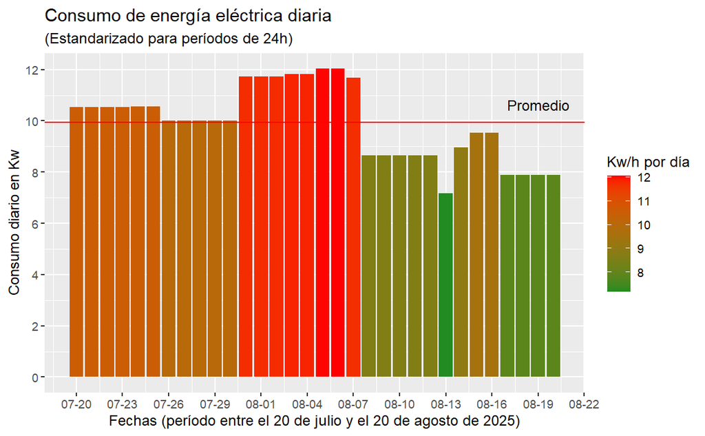

### 3.4. Datos para tener en cuenta

#### 3.4.1. Diferencias sobre datos de consumo

Entre los datos que reporta Air-e en sus lecturas y los recolectados de la información que suministra el contador, aparecen diferencias de consumo. Estas diferencias no deben ser muy altas y se deben principalmente a la hora en que se recolectan los datos. Normalmente las diferencias se compensan en la factura del siguiente período. La siguiente tabla muestra estas diferencias para este mes:

| Factura Air-e | Lectura Contador | Número de días | Diferencia |
| --- | --- | --- | --- |
| 310 Kw | 317.84 Kw | 32 días | 7.84 Kw (a favor nuestro). |

#### 3.4.2. Valor de corte

Anteriormente se tenía establecido un valor de corte en 14 Kw por día. Ante los cambios debidos al arreglo del cableado interno el nuevo valor de corte será establecido en 10 Kw por día, por su cercanía al promedio actual presentado en la gráfica anterior. Este valor permite observar las tendencias en el consumo mes a mes (aumentos o disminuciones en los promedios de consumo).

Este mes hemos disminuido el promedio de consumo en 4.068 Kw por día con respecto al corte que se tenía el mes anterior.

#### 3.4.3. Valor del consumo del aire acondicionado

A partir del presente mes queda incluido en el valor del consumo bajo el respectivo contador. Esta sección del documento también desaparecerá en versiones posteriores del mismo.

#### 3.4.4. Lectura de contadores internos

A partir del presente mes se presentan en la siguiente tabla las lecturas de los contadores internos de cada subdivisión de los circuitos de la casa (Habitaciones y apartamento). Se les recuerda que el area común, desde la cocina hasta la lavandería, no han quedado cobijados bajo ningún contador por lo que la sumatoria de los valores de consumo de los contadores internos seguramente será menor al consumo total, haciéndose necesaria la repartición de esta diferencia, la cual se hará de manera proporcional al consumo obtenido de dichos contadores a partir del próximo mes.

| Habitación | Contador # | Lectura final | Lectura inicial | Consumo Kw |
| --- | --- | --- | --- | --- |
| Hab. 1 | 24177828 | 54.89 | 3.07 | 51.82 |
| Hab. 2 | 24178030 | 24.17 | 3.10 | 21.07 |
| Hab. 3 | 24176587 | 3.23 | 3.05 | 0.18 |
| Apt. | 24178159 | 48.94 | 3.12 | 45.82 |

```
La última lectura de los contadores internos se realizó el 19 de agosto de 2025; la lectura anterior se hizo el 2 de agosto de 2025.
La suma total de los consumos es de 118.89 Kw. Quedando un consumo a repartir de 191.11 Kw.
```

#### 3.4.5 Consumo area común

Por esta última vez, debido al ajuste por el cambio de contadores, la energía eléctrica consumida no cubierta por los contadores internos se repartirá de acuerdo a la tabla de ponderación. A partir de la siguiente factura se repartirá de manera proporcional al consumo reportado por dichos contadores.

| Habitación | Consumo Contador | Consumo Area Común (Ponderado) | Total Consumo Kw |
| --- | --- | --- | --- |
| Hab. 1 | 51.82 | 76.44 | 128.26 |
| Hab. 2 | 21.07 | 33.44 | 54.51 |
| Hab. 3 | 0.18 | 4.78 | 4.96 |
| Apt. | 45.82 | 76.44 | 122.26 |

### 3.5. Total a pagar por habitación

| Habitación | Integrante(s) | Costo Energía |
| --- | --- | --- |
| Hab. 1 | Andresito y Kevin | $110.100 |
| Hab. 2 | Jorge | $46.800 |
| Hab. 3 | Gary | $4.300 |
| Apt. | Luis y Andrés | $104.900 |

###### Tabla de contenidos

## 4. Movistar

Los siguientes son los datos de la factura de Movistar por concepto del internet:

El valor total de la factura del Internet por $94.990, con referencia de pago 60512751061, está para pagar antes del 10 de septiembre de 2025. Equivalente a $19.000 por persona (5).

###### Tabla de contenidos

## 5. Total Servicios

El total de los servicios por habitación se discrimina a continuación:

| Habitación | TripleA | Air-e | Movistar | Total Servicios |
| --- | --- | --- | --- | --- |
| Hab. 1 | $107.600 | $110.100 | $38.000 | $255.700 |
| Hab. 2 | $53.800 | $46.800 | $19.000 | $119.600 |
| Hab. 3 | $17.900 | $4.300 | $0 | $22.200 |
| Apt. | $107.600 | $104.900 | $38.000 | $250.500 |

###### Tabla de contenidos